# Initial firm size distribution

Use `sample_size_tb` to compare annual log sales distributions and mean excess functions for 2010–2020 among observations at firm age five. Corresponding to income at age 25 in the income analysis, sales at firm age five are treated as initial size in the firm analysis. Initial size here refers to sales at firm age five rather than sales at establishment.

## 1 Data preparation

```r
library(tidyverse)
library(pins)
library(hrbrthemes)
theme_set(theme_ipsum(base_size = 12, axis_title_size = 13))
board <- board_folder("../Zipf_law_board_replicate_simulation")
```

Calculate firm age `age` as observation year `year` minus establishment year `birth_year`, and retain observations meeting the following conditions in `init_size_tb`.

- Firm age is five.
- Observation year is from 2010 through 2020.
- The first two digits of industry code `ind_class` are 01–61 or 68–92.
- Sales `sale` are positive.

Original sales `sale` are measured in thousands of yen; multiply by 1000 to convert to yen when creating each figure.

```r
library(scattermore)

sample_size_tb <- board |> pin_read("sample_size_tb", type = "qs2") |>
  mutate(age = as.numeric(year) - birth_year)

init_size_tb <- sample_size_tb |>
  filter(age == 5,
         sale > 0,
         as.numeric(year) >= 2010, as.numeric(year) <= 2020,
         str_sub(ind_class, 1,2) %in% str_pad(c(1:61, 68:92), 2, pad = 0))
```

## 2 Density estimation

As with annual log income distributions in the income analysis, compare log sales distributions in the firm analysis using density plots. Display sales in yen from $10^4$ to $10^{12}$ and density from $10^{-3.5}$ to $10^{0.1}$.

The first figure uses 2010 only and estimates density from observations with sales below $10^{13}$ after conversion to yen.

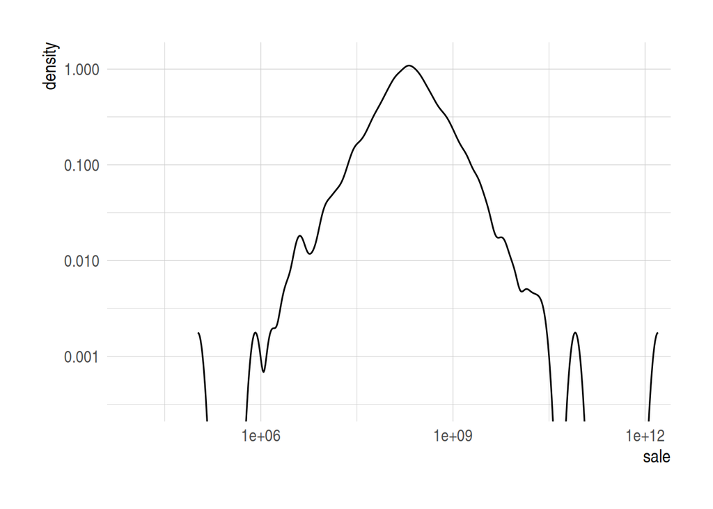

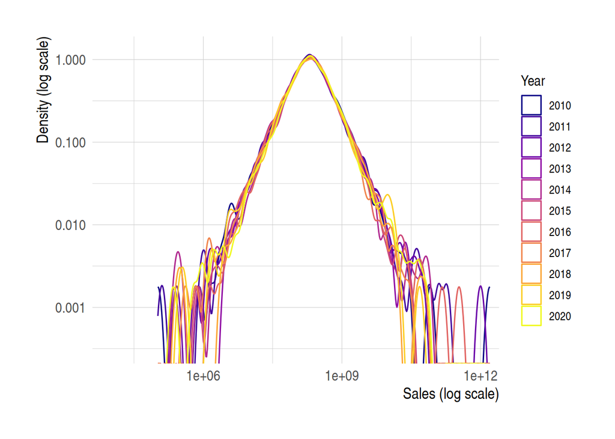

```r
init_size_tb |>
  mutate(sale = sale * 1000) |>
  filter(year == "2010", sale < 10^13) |>
ggplot() +
  geom_density(aes(sale)) +
  scale_x_log10() + scale_y_log10() +
  coord_cartesian(xlim = c(10^4, 10^12), ylim = c(10^{-3.5}, 10^{0.1}))
ggsave(filename = "init_size_age_5.png", path = "graph")

init_size_tb |>
  mutate(sale = sale * 1000) |>
ggplot() +
  geom_density(aes(sale, color = year)) +
  scale_color_viridis_d(option = "C") +
  scale_x_log10() + scale_y_log10() +
  coord_cartesian(xlim = c(10^4, 10^12), ylim = c(10^{-3.5}, 10^{0.1})) +
  labs(
      x = "Sales (log scale)",
      y = "Density (log scale)",
      color = "Year",
  ) +
  theme(axis.title = element_text(face = "bold"))
ggsave(filename = "init_size_diff_birth_age_5.png", path = "graph")
```

## 3 Mean Excess Function

Corresponding to natural log income in the income analysis, use the natural logarithm of sales converted to yen, $L=\log(\mathrm{sale})$, in the firm analysis. Let $L_{(i)}$ denote values in descending order within each year. The calculation is as follows.

$$m_{\mathrm{excess},i}=\frac{1}{i-1}\sum_{j=1}^{i-1}L_{(j)}-L_{(i)}, \qquad i\geq2.$$

Use the natural log sales threshold on the horizontal axis, displaying values from $\log(10^8)$ to $\log(10^{10})$ and a vertical range of 0.75–1.5. Include observations outside the displayed range when calculating cumulative means.

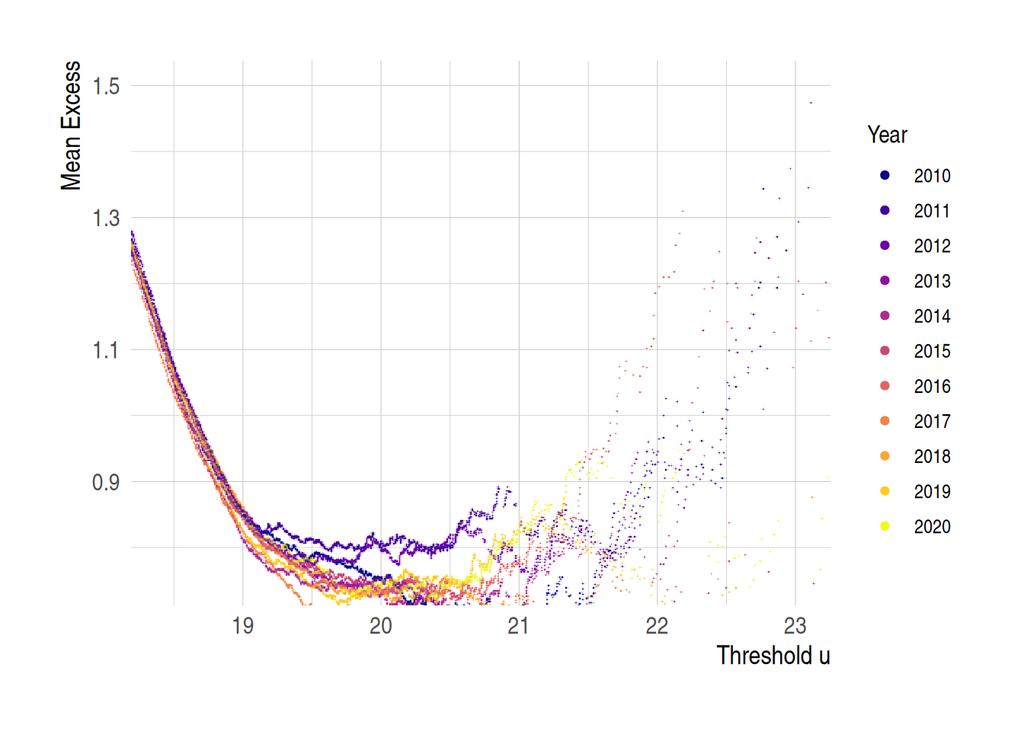

```r
init_size_tb |>
  mutate(sale = sale * 1000) |>
  mutate(log_sale = log(sale)) |>
    arrange(desc(sale)) |>
    group_by(year) |>
    mutate(m_excess = lag(cummean(log_sale)) - log_sale) |>
  ggplot(aes(log_sale, m_excess, color = year)) +
    geom_scattermore(pointsize = 1.2) +
    scale_color_viridis_d(option = "C") +
  coord_cartesian(xlim = c(log(10^8), log(10^{10})), ylim = c(0.75, 1.5)) +
  labs(
      x = "Threshold u",
      y = "Mean Excess",
      color = "Year",
  ) +
  theme(axis.title = element_text(face = "bold"))
ggsave(filename = "mean_excess_init_size_age_5.png", path = "graph")
```